# Определение возраста покупателей

**Описание задачи**

Сетевой супермаркет «Хлеб-Соль» внедряет систему компьютерного зрения для автоматического определения возраста покупателей по фотографиям, сделанным в прикассовой зоне. Эта система необходима для решения двух ключевых задач:

- **Анализ покупательского поведения**: выявление закономерностей между возрастом клиентов и их выбором товаров. Это позволит формировать персонализированные предложения и рекламные акции, ориентированные на конкретные возрастные группы.
- **Контроль соблюдения возрастных ограничений**: предотвращение случаев продажи алкогольной продукции несовершеннолетним за счет автоматической проверки возраста.

Цель проекта — создать свёрточную нейронную сеть (CNN), которая по изображению лица человека предсказывает его возраст. Модель должна достигать значения **MAE (средняя абсолютная ошибка) не более 8** на тестовой выборке.

**Исходные данные**

**Структура данных** Датасет состоит из:

1. **CSV-файла `labels.csv`**:
   - Содержит два столбца:
     - `file_name` — имя файла изображения.
     - `real_age` — реальный возраст человека на изображении (целое число от 1 до 100).
2. **Папки `final_files`**:
   - Содержит изображения, соответствующие записям в `labels.csv`.
   - Пример: для строки `0001.jpg, 50` в `labels.csv` должен существовать файл `final_files/0001.jpg`.

**Характеристики данных**

- **Объем датасета**: **7591** - изображений, данные охватывают широкий диапазон возрастов (от детей до пожилых людей).
- **Разметка**: Возраст указан для каждого изображения.
- **Разрешение изображений**: Для обучения модели все изображения приводятся к размеру **150×150 пикселей** (требование тренажера).

**Подготовка данных**

- **Разделение выборки**: Обучающая и валидационная выборки выделяются через параметр `validation_split=0.25` в `ImageDataGenerator`.
  - Обучающая: 75% данных (`subset='training'`).
  - Тестовая: 25% данных (`subset='validation'`).

## Исследовательский анализ данных

```python
import pandas as pd
import matplotlib.pyplot as plt
import seaborn as sns
from keras.preprocessing.image import ImageDataGenerator
```

```python
labels = pd.read_csv('/datasets/faces/labels.csv')
```

```python
# Функция для ознакомления с таблицами
def first_check(data, dataset_name=""):
    # Печатаем название датасета
    if dataset_name:
        print(f"Анализ датасета: {dataset_name}")
    else:
        print("Анализ датасета")
    print("=" * 40 + "\n")

    # Первые и последние строки
    print("Первые 5 строк:")
    display(data.head())
    print("\nПоследние 5 строк:")
    display(data.tail())

    # Информация о данных
    print("\nИнформация о данных:")
    display(data.info())

    # Описательная статистика
    print("\nОписательная статистика:")
    display(data.describe(include='all'))
```

```python
first_check(labels)
```

```
Анализ датасета
========================================

Первые 5 строк:
```

|  | file_name | real_age |
| --- | --- | --- |
| 0 | 000000.jpg | 4 |
| 1 | 000001.jpg | 18 |
| 2 | 000002.jpg | 80 |
| 3 | 000003.jpg | 50 |
| 4 | 000004.jpg | 17 |

```
Последние 5 строк:
```

|  | file_name | real_age |
| --- | --- | --- |
| 7586 | 007608.jpg | 14 |
| 7587 | 007609.jpg | 37 |
| 7588 | 007610.jpg | 28 |
| 7589 | 007611.jpg | 20 |
| 7590 | 007612.jpg | 47 |

```
Информация о данных:
<class 'pandas.core.frame.DataFrame'>
RangeIndex: 7591 entries, 0 to 7590
Data columns (total 2 columns):
 #   Column     Non-Null Count  Dtype
---  ------     --------------  -----
 0   file_name  7591 non-null   object
 1   real_age   7591 non-null   int64
dtypes: int64(1), object(1)
memory usage: 118.7+ KB
```

```
None
```

```
Описательная статистика:
```

|  | file_name | real_age |
| --- | --- | --- |
| count | 7591 | 7591.000000 |
| unique | 7591 | NaN |
| top | 000780.jpg | NaN |
| freq | 1 | NaN |
| mean | NaN | 31.201159 |
| std | NaN | 17.145060 |
| min | NaN | 1.000000 |
| 25% | NaN | 20.000000 |
| 50% | NaN | 29.000000 |
| 75% | NaN | 41.000000 |
| max | NaN | 100.000000 |

Выборка состоит из 7591 фотографии. Дубликаты и пропуски не обнаружены.

Изучим данные подробнее.

```python
train_datagen = ImageDataGenerator(rescale=1./255)
train_gen_flow = train_datagen.flow_from_dataframe(
        dataframe=labels,
        directory='/datasets/faces/final_files/',
        x_col='file_name',
        y_col='real_age',
        target_size=(224, 224),
        batch_size=16,
        class_mode='raw',
        seed=12345)
```

```
Found 7591 validated image filenames.
```

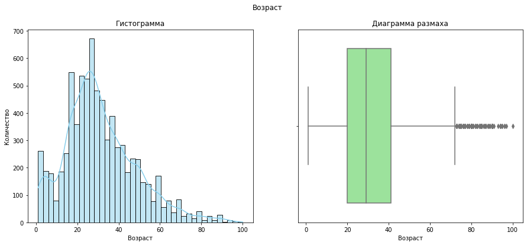

```python
fig, axs = plt.subplots(nrows=1 , ncols=2, figsize=(15, 6))
sns.histplot(data=labels, x='real_age', ax=axs[0], bins = 40, kde=True, color='skyblue')
axs[0].set_xlabel('Возраст')
axs[0].set_ylabel('Количество')
axs[0].set_title('Гистограмма')
sns.boxplot(data=labels, x='real_age', ax=axs[1], color='lightgreen')
axs[1].set_xlabel('Возраст')
axs[1].set_title('Диаграмма размаха')
fig.suptitle('Возраст')
plt.show()
```

[figure not shown]

```python
images, labels = next(train_gen_flow)
plt.figure(figsize=(20, 10))
for i in range(10):
    plt.subplot(2, 5, i + 1)
    plt.imshow(images[i])
    plt.title(f'Age: {labels[i]}')
    plt.axis('off')
plt.show()
```

```python
images.shape
```

```
(16, 224, 224, 3)
```

## Обучение модели

Перенесите сюда код обучения модели и её результат вывода на экран.

(Код в этом разделе запускается в отдельном GPU-тренажёре, поэтому оформлен не как ячейка с кодом, а как код в текстовой ячейке)

```
import pandas as pd
from tensorflow.keras.preprocessing.image import ImageDataGenerator
from tensorflow.keras.models import Sequential
from tensorflow.keras.layers import Dense, GlobalAveragePooling2D
from tensorflow.keras.applications.resnet import ResNet50
from tensorflow.keras.optimizers import Adam

def load_train(path):
    labels = pd.read_csv(f'{path}/labels.csv')
    datagen = ImageDataGenerator(validation_split=0.25, rescale=1./255)

    train_flow = datagen.flow_from_dataframe(
        dataframe=labels,
        x_col='file_name',
        y_col='real_age',
        class_mode='raw',
        subset='training',
        directory=f'{path}/final_files/',
        target_size=(150, 150),
        batch_size=16,
        seed=12345,
        shuffle=True
    )
    return train_flow

def load_test(path):
    labels = pd.read_csv(f'{path}/labels.csv')
    datagen = ImageDataGenerator(validation_split=0.25, rescale=1./255)

    test_flow = datagen.flow_from_dataframe(
        dataframe=labels,
        x_col='file_name',
        y_col='real_age',
        class_mode='raw',
        subset='validation',
        directory=f'{path}/final_files/',
        target_size=(150, 150),
        batch_size=16,
        seed=12345,
        shuffle=False
    )
    return test_flow

def create_model(input_shape):
    model = Sequential()
    backbone = ResNet50(
        input_shape=input_shape,
        weights='/datasets/keras_models/resnet50_weights_tf_dim_ordering_tf_kernels_notop.h5',
        include_top=False
    )
    model.add(backbone)
    model.add(GlobalAveragePooling2D())
    model.add(Dense(1))  # Без активации для регрессии

    model.compile(
        optimizer=Adam(learning_rate=0.0001),
        loss='mae',
        metrics=['mae']
    )
    return model

def train_model(model, train_data, test_data, batch_size=None, epochs=5,
                steps_per_epoch=None, validation_steps=None):
    model.fit(
        train_data,
        validation_data=test_data,
        batch_size=batch_size,
        epochs=epochs,
        steps_per_epoch=steps_per_epoch,
        validation_steps=validation_steps,
        verbose=2
    )
    return model
```

```
Found 5694 validated image filenames.
Found 1897 validated image filenames.

Train for 356 steps, validate for 119 steps
Epoch 1/5
356/356 - 74s - loss: 10.8280 - mae: 10.8294 - val_loss: 13.2728 - val_mae: 13.2980
Epoch 2/5
356/356 - 42s - loss: 7.3414 - mae: 7.3411 - val_loss: 9.9460 - val_mae: 9.9314
Epoch 3/5
356/356 - 41s - loss: 6.1308 - mae: 6.1308 - val_loss: 7.9260 - val_mae: 7.9219
Epoch 4/5
356/356 - 42s - loss: 5.2370 - mae: 5.2373 - val_loss: 7.7362 - val_mae: 7.7389
Epoch 5/5
356/356 - 43s - loss: 4.7145 - mae: 4.7144 - val_loss: 6.9717 - val_mae: 6.9746

119/119 - 10s - loss: 6.9717 - mae: 6.9746
```

## Анализ обученной модели

**Результаты обучения**

1. Финальные метрики на валидационной выборке:
- **Loss**: 6.97
- **MAE** (средняя абсолютная ошибка): 6.97 Это значение ниже целевого порога 8, что соответствует требованиям проекта.
2. Динамика обучения:
- 1-я эпоха: **MAE** на тренировочной выборке — **10.83**, на валидационной — **13.30**.
- 5-я эпоха: **MA**E на тренировочной выборке — **4.71**, на валидационной — **6.97**. Модель демонстрирует устойчивое снижение ошибки.